# Workshop: Earth Observation for Official Statistics - Working with raster data

`{r } ndvCalc <- function(x) { ndvi <- (x[[4]] - x[[3]]) / (x[[4]] + x[[3]]) return(ndvi) } ndvi2 <- calc(x=gewata, fun=ndvCalc)` Plot ndvi2. This will produce the same result as the plot of ndvi

`{r } plot(ndvi2)`

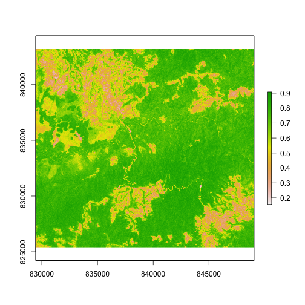

Alternative function

`{r } ndvOver <- function(x, y) { ndvi <- (y - x) / (x + y) return(ndvi) } ndvi3 <- overlay(x=gewata[[3]], y=gewata[[4]], fun=ndvOver)`

We currently don’t know where this area we are plotting is on a map. To investigate this, we can project it in Google earth by using latitute and longitude Obtain the latitude and longitude of our NDVI layer One single line is sufficient to project any raster to any projection

`{r } ndviLL <- projectRaster(ndvi, crs='+proj=longlat')` Since this function will write a file to your working directory You want to make sure that it is set where you want the file to be written, so check your current working directory

`{r } getwd()` It can be changed using setwd()

Save the latitude and longitude of the NDVI layer to a .kml file, because this file type is a Google earth format

`{r } KML(x=ndviLL, filename='gewataNDVI.kml')` Once you have saved the file, if you navigate to the file on your computer and double click, it will open in Google Earth and show you where this area appears on a map

Using cloud masks in R A cloud mask is an extra raster layer, that contains information about presence or absence of cloud and shaowing effects from clouds cfmask is the cloud mask of Landsat surface reflectance product In this example, we will use the cfmask layer to mask remaining clouds out of a Landsat image of Tahiti, French Polynesia Download the data and unzip the file

`{r } download.file(url='https://raw.githubusercontent.com/GeoScripting-WUR/IntroToRaster/gh-pages/data/tahiti.zip', destfile='tahiti.zip', method='auto') unzip(zipfile='tahiti.zip')` Load the data as a RasterBrick object called ‘Tahiti’ and look at its metadata

`{r } tahiti <- brick('LE70530722000126_sub.grd') tahiti`

```
## class       : RasterBrick
## dimensions  : 1014, 1322, 1340508, 7  (nrow, ncol, ncell, nlayers)
## resolution  : 30, 30  (x, y)
## extent      : 224380.7, 264040.7, 8029882, 8060302  (xmin, xmax, ymin, ymax)
## coord. ref. : +proj=utm +zone=6 +south +ellps=WGS72 +units=m +no_defs
## data source : /Users/hollowj/Documents/RA/UN/R/Earth Observation Workshop/LE70530722000126_sub.grd
## names       : LE70530722000126_sub_band1, LE70530722000126_sub_band2, LE70530722000126_sub_band3, LE70530722000126_sub_band4, LE70530722000126_sub_band5, LE70530722000126_sub_band7, LE7053072//sub_cfmask
## min values  :                          0,                          0,                          0,                          0,                          0,                          0,                     0
## max values  :                      16000,                      16000,                      16000,                      16000,                      16000,                      16000,                     4
```

The metadata tells us the Tahiti RasterBrick is 1014 by 1322 pixels and has 7 layers Display names of each individual layer

`{r } names(tahiti)`

```
## [1] "LE70530722000126_sub_band1"  "LE70530722000126_sub_band2"
## [3] "LE70530722000126_sub_band3"  "LE70530722000126_sub_band4"
## [5] "LE70530722000126_sub_band5"  "LE70530722000126_sub_band7"
## [7] "LE70530722000126_sub_cfmask"
```

Visualize the data

`{r } plotRGB(tahiti, 3,4,5)`

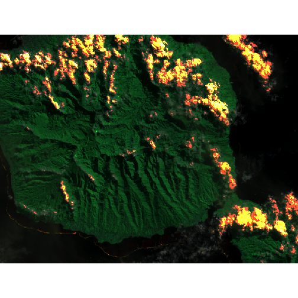

Visualize the cloud mask layer (layer 7)

`{r } plot(tahiti, 7)`

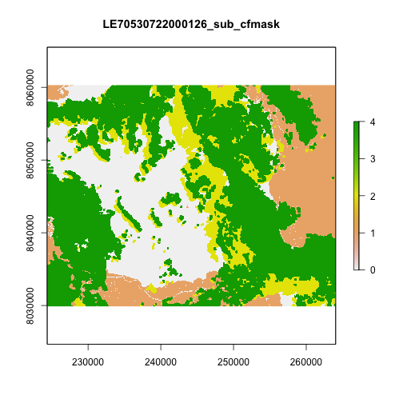

1 = water, 2 = cloud shadow, 3 = snow, 4 = cloud (see https://code.google.com/p/fmask/) We can plot the cloud layer on top of the RGB image of Tahiti. To do this, we need to assign NA values to the ‘clear land pixels’ so they appear transparent on the overlay plot Extract cloud layer from the brick

`{r } cloud <- tahiti[[7]]`

Replace ‘clear land’ with ‘NA’

`{r } cloud[cloud == 0] <- NA`

Plot the stack and the cloud mask on top of each other

`{r } plotRGB(tahiti, 3,4,5) plot(cloud, add = TRUE, legend = FALSE)`

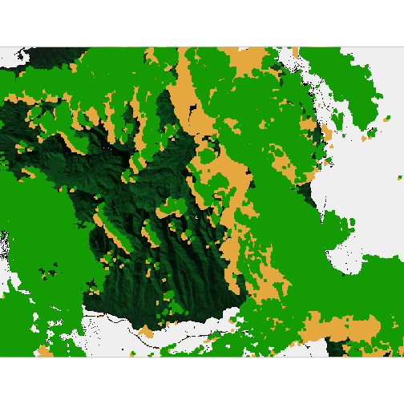

It is easier to work on the cloud mask as a separate RasterLayer, so we will extract it Extract cloud mask RasterLayer into an object called ‘fmask’

`{r } fmask <- tahiti[[7]]`

Remove fmask layer from the Landsat stack and call it ‘tahiti 6’

`{r } tahiti6 <- dropLayer(tahiti, 7)`

We will first do the masking using simple vector arithmetic, as if tahiti6 and fmask were simple vectors. Since we are assigning NAs, we want to discard any value of the stack which has a corresponding cloud mask pixel different from 0. This can be done in one line of code below Perform value replacement

`{r } tahiti6[fmask != 0] <- NA`

This approach is only suitable if the objects and values you are working with are very small. This is often not the case with satellite iamgery, so we will use a replacement function instead Define a value replacement function. x corresponds to the RasterBrick and y to the cloud mask

`{r } cloud2NA <- function(x, y){ x[y != 0] <- NA return(x) }`

Let’s create a new 6 layered object, called tahiti6_2, since tahiti6 has been masked already

`{r } tahiti6_2 <- dropLayer(tahiti, 7)`

Apply the function on the two raster objects using overlay, creating an object called tahitiCloudFree

`{r } tahitiCloudFree <- overlay(x = tahiti6_2, y = fmask, fun = cloud2NA)`

Visualize the output

`{r } plotRGB(tahitiCloudFree, 3,4,5)`

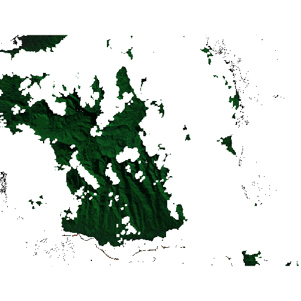

In this plot the clouds are now gone. If you wanted to extend on this, you could use another image from another date to create a composited image to ‘fill in the gaps’